# Implementing Moving Average on Time Series Data

### Simple Moving Average (SMA)

A moving average, also called a rolling or running average, is used to analyze the time-series data by calculating averages of different subsets of the complete dataset. Since it involves taking the average of the dataset over time, it is also called a moving mean (MM) or rolling mean.

There are various ways in which the rolling average can be calculated, but one such way is to take a fixed subset from a complete series of numbers. The first moving average is calculated by averaging the first fixed subset of numbers, and then the subset is changed by moving forward to the next fixed subset.

The moving average is mostly used with time series data to capture the short-term fluctuations while focusing on longer trends. A few examples of time series data can be stock prices, weather reports, air quality, gross domestic product, employment, etc. In general, the moving average smoothens the data.

Moving average is a backbone to many algorithms, and one such algorithm is Autoregressive Integrated Moving Average Model (ARIMA), which uses moving averages to make time series data predictions. There are various types of moving averages:

Simple Moving Average (SMA): Simple Moving Average (SMA) uses a sliding window to take the average over a set number of time periods. It is an equally weighted mean of the previous n data.

Exponential Moving Average (EMA): Unlike SMA and CMA, exponential moving average gives more weight to the recent prices and as a result of which, it can be a better model or better capture the movement of the trend in a faster way. EMA's reaction is directly proportional to the pattern of the data. Since EMAs give a higher weight on recent data than on older data, they are more responsive to the latest price changes as compared to SMAs, which makes the results from EMAs more timely and hence EMA is more preferred over other techniques.

```python
import pandas as pd
import numpy as np
product = {'month' : [1,2,3,4,5,6,7,8,9,10,11,12],'demand':[290,260,288,300,310,303,329,340,316,330,308,310]}
df = pd.DataFrame(product)
df.head()
```

|  | month | demand |
| --- | --- | --- |
| 0 | 1 | 290 |
| 1 | 2 | 260 |
| 2 | 3 | 288 |
| 3 | 4 | 300 |
| 4 | 5 | 310 |

```python
Let's calculate SMA for a window size of 3, which means you will consider three values each time to calculate the moving average,
and for every new value, the oldest value will be ignored.
To implement this, you will use pandas iloc function, since the demand column is what you need, you will fix the position
of that in the iloc function while the row will be a variable i which you will keep iterating until you reach the end of the dataframe.
```

```python
df.shape
```

```
(12, 2)
```

```python
df.shape[0]
```

```
12
```

```python
df.loc[df.index[0]]
```

```
month       1
demand    290
Name: 0, dtype: int64
```

```python
for i in range(0,10):     # i.e., 12 -2
    df.loc[df.index[i+2],'SMA_3'] = np.round(((df.iloc[i,1]+ df.iloc[i+1,1] +df.iloc[i+2,1])/3),1)
df
```

|  | month | demand | SMA_3 |
| --- | --- | --- | --- |
| 0 | 1 | 290 | NaN |
| 1 | 2 | 260 | NaN |
| 2 | 3 | 288 | 279.3 |
| 3 | 4 | 300 | 282.7 |
| 4 | 5 | 310 | 299.3 |
| 5 | 6 | 303 | 304.3 |
| 6 | 7 | 329 | 314.0 |
| 7 | 8 | 340 | 324.0 |
| 8 | 9 | 316 | 328.3 |
| 9 | 10 | 330 | 328.7 |
| 10 | 11 | 308 | 318.0 |
| 11 | 12 | 310 | 316.0 |

```python
i=1
df.iloc[i+1,1]
```

```
288
```

```python
# generalise where total_rows - 2 is (df.shape[0]-2)
for i in range(0,df.shape[0]-2):
    df.loc[df.index[i+2],'SMA_3'] = np.round(((df.iloc[i,1]+ df.iloc[i+1,1] +df.iloc[i+2,1])/3),1)
df
```

|  | month | demand | SMA_3 |
| --- | --- | --- | --- |
| 0 | 1 | 290 | NaN |
| 1 | 2 | 260 | NaN |
| 2 | 3 | 288 | 279.3 |
| 3 | 4 | 300 | 282.7 |
| 4 | 5 | 310 | 299.3 |
| 5 | 6 | 303 | 304.3 |
| 6 | 7 | 329 | 314.0 |
| 7 | 8 | 340 | 324.0 |
| 8 | 9 | 316 | 328.3 |
| 9 | 10 | 330 | 328.7 |
| 10 | 11 | 308 | 318.0 |
| 11 | 12 | 310 | 316.0 |

```python
check: use the pandas in-built rolling function and see if it matches with the custom python based simple moving average.
```

```python
df['pandas_SMA_3'] = df.iloc[:,1].rolling(window=3).mean()
```

```python
df.head()
```

|  | month | demand | SMA_3 | pandas_SMA_3 |
| --- | --- | --- | --- | --- |
| 0 | 1 | 290 | NaN | NaN |
| 1 | 2 | 260 | NaN | NaN |
| 2 | 3 | 288 | 279.3 | 279.333333 |
| 3 | 4 | 300 | 282.7 | 282.666667 |
| 4 | 5 | 310 | 299.3 | 299.333333 |

```python
The first rows of the returned series contain null values since rolling needs a minimum of n values (value specified in the window argument)
to return the mean. We can change this behavior by modifying the argument min_periods as follows.
rolling(window=3, min_periods=1).mean()
```

```python
#calculate the simple moving average for a window_size of 4.

for i in range(0,df.shape[0]-3):
    df.loc[df.index[i+3],'SMA_4'] = np.round(((df.iloc[i,1]+ df.iloc[i+1,1] +df.iloc[i+2,1]+df.iloc[i+3,1])/4),1)
```

```python
df.head()
```

[output not shown]

```python
df['pandas_SMA_4'] = df.iloc[:,1].rolling(window=4).mean()
df.head()
```

[output not shown]

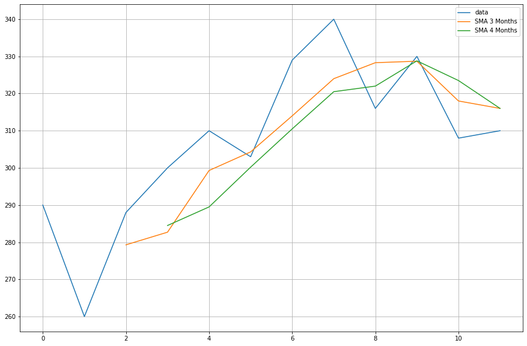

```python
#Now, plot the data of the moving averages calculated.

import matplotlib.pyplot as plt
%matplotlib inline
plt.figure(figsize=[15,10])
plt.grid(True)
plt.plot(df['demand'],label='data')
plt.plot(df['SMA_3'],label='SMA 3 Months')
plt.plot(df['SMA_4'],label='SMA 4 Months')
plt.legend(loc=1)
```

```python
Cumulative Moving Average.. move to a real dataset.
```

```python
import os
```

```python
os.chdir("")
```

```python
df = pd.read_csv("E:/2020/BA/classes_BA_2020/Unit-III/Ch16 Time Series Forecasting/Time Series Forecasting/data_time_series/AirQualityUCI/AirQualityUCI.csv", sep = ";", decimal = ",")
```

```python
#df.describe
```

```python
df.shape
```

```
(9471, 17)
```

```python
df.columns
```

```
Index(['Date', 'Time', 'CO(GT)', 'PT08.S1(CO)', 'NMHC(GT)', 'C6H6(GT)',
       'PT08.S2(NMHC)', 'NOx(GT)', 'PT08.S3(NOx)', 'NO2(GT)', 'PT08.S4(NO2)',
       'PT08.S5(O3)', 'T', 'RH', 'AH', 'Unnamed: 15', 'Unnamed: 16'],
      dtype='object')
```

```python
df = df.iloc[ : , 0:14]
```

Preprocessing First: check for NaN (Null) values. NaN values can be replaced them with either 0 or average or preceding or succeeding values or even drop them. Though replacing is normally a better choice over dropping them, since this dataset has few NULL values, dropping them will not affect the continuity of the series.

```python
df.isna().sum()
```

```
Date             114
Time             114
CO(GT)           114
PT08.S1(CO)      114
NMHC(GT)         114
C6H6(GT)         114
PT08.S2(NMHC)    114
NOx(GT)          114
PT08.S3(NOx)     114
NO2(GT)          114
PT08.S4(NO2)     114
PT08.S5(O3)      114
T                114
RH               114
dtype: int64
```

```python
From the above output, you can observe that there are around 114 NaN values across all columns, however they are all at
the end of the time-series, so drop them.
```

```python
df.dropna(inplace=True)
```

```python
df.isna().sum()
```

```
Date             0
Time             0
CO(GT)           0
PT08.S1(CO)      0
NMHC(GT)         0
C6H6(GT)         0
PT08.S2(NMHC)    0
NOx(GT)          0
PT08.S3(NOx)     0
NO2(GT)          0
PT08.S4(NO2)     0
PT08.S5(O3)      0
T                0
RH               0
dtype: int64
```

```python
#Will be applying cumulative moving average on the Temperature column (T), so separate that column out from the complete data.
df_T = pd.DataFrame(df.iloc[:,-2])
df_T.head()
```

|  | T |
| --- | --- |
| 0 | 13.6 |
| 1 | 13.3 |
| 2 | 11.9 |
| 3 | 11.0 |
| 4 | 11.2 |

Use the pandas expanding method fo find the cumulative average of the above data....unlike the simple moving average, the cumulative moving average considers all of the preceding values when calculating the average.

```python
df_T['CMA_4'] = df_T.expanding(min_periods=4).mean()
```

```python
df_T.head(10)
```

|  | T | CMA_4 |
| --- | --- | --- |
| 0 | 13.6 | NaN |
| 1 | 13.3 | NaN |
| 2 | 11.9 | NaN |
| 3 | 11.0 | 12.450000 |
| 4 | 11.2 | 12.200000 |
| 5 | 11.2 | 12.033333 |
| 6 | 11.3 | 11.928571 |
| 7 | 10.7 | 11.775000 |
| 8 | 10.7 | 11.655556 |
| 9 | 10.3 | 11.520000 |

```python
Time series data is plotted with respect to the time, so combine the date and time column and convert it into a datetime object.
...the datetime module from python (Source: Time Series Tutorial).
```

```python
import datetime
df['DateTime'] = (df.Date) + ' ' + (df.Time)
```

```python
#df.describe  A new column added
```

```python
df['DateTime']
```

```
0       10/03/2004 18.00.00
1       10/03/2004 19.00.00
2       10/03/2004 20.00.00
3       10/03/2004 21.00.00
4       10/03/2004 22.00.00
               ...
9352    04/04/2005 10.00.00
9353    04/04/2005 11.00.00
9354    04/04/2005 12.00.00
9355    04/04/2005 13.00.00
9356    04/04/2005 14.00.00
Name: DateTime, Length: 9357, dtype: object
```

```python
df.DateTime = df.DateTime.apply(lambda x: datetime.datetime.strptime(x, '%d/%m/%Y %H.%M.%S'))
```

```python
df['DateTime'].head(3)
```

```
0   2004-03-10 18:00:00
1   2004-03-10 19:00:00
2   2004-03-10 20:00:00
Name: DateTime, dtype: datetime64[ns]
```

```python
#change the index of the temperature dataframe with datetime.
df_T.index = df.DateTime
```

```python
df_T.tail(20)
```

[output not shown]

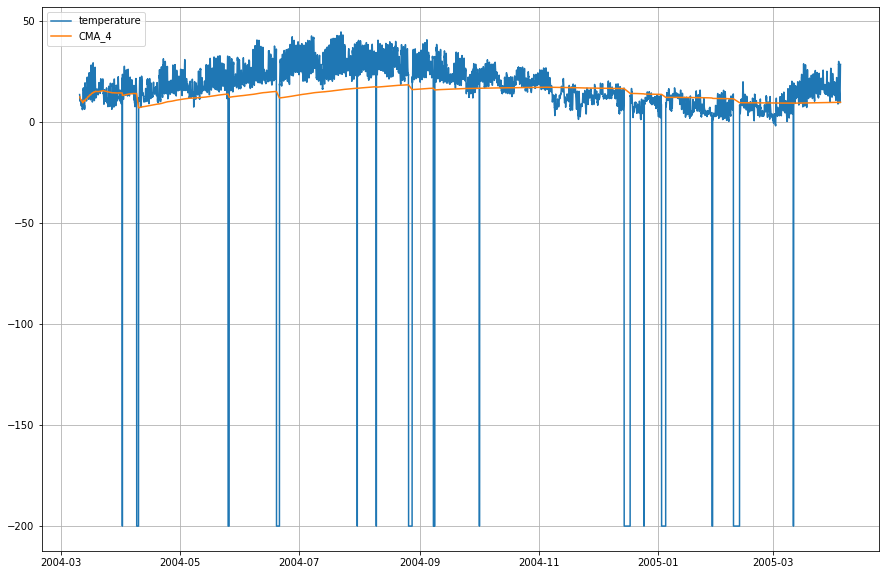

```python
# plot the actual temperature and the cumulative moving average wrt. time.
plt.figure(figsize=[15,10])
plt.grid(True)
plt.plot(df_T['T'],label='temperature')
plt.plot(df_T['CMA_4'],label='CMA_4')
plt.legend(loc=2);
```

```python
#Exponential Moving Average
df_T['EMA'] = df_T.iloc[:,0].ewm(span=40,adjust=False).mean()
df_T
```

| DateTime | T | CMA_4 | EMA |
| --- | --- | --- | --- |
| 2004-03-10 18:00:00 | 13.6 | NaN | 13.600000 |
| 2004-03-10 19:00:00 | 13.3 | NaN | 13.585366 |
| 2004-03-10 20:00:00 | 11.9 | NaN | 13.503153 |
| 2004-03-10 21:00:00 | 11.0 | 12.450000 | 13.381048 |
| 2004-03-10 22:00:00 | 11.2 | 12.200000 | 13.274655 |
| ... | ... | ... | ... |
| 2005-04-04 10:00:00 | 21.9 | 9.770940 | 16.366986 |
| 2005-04-04 11:00:00 | 24.3 | 9.772493 | 16.753962 |
| 2005-04-04 12:00:00 | 26.9 | 9.774324 | 17.248891 |
| 2005-04-04 13:00:00 | 28.3 | 9.776304 | 17.787969 |
| 2005-04-04 14:00:00 | 28.5 | 9.778305 | 18.310507 |

9357 rows × 3 columns

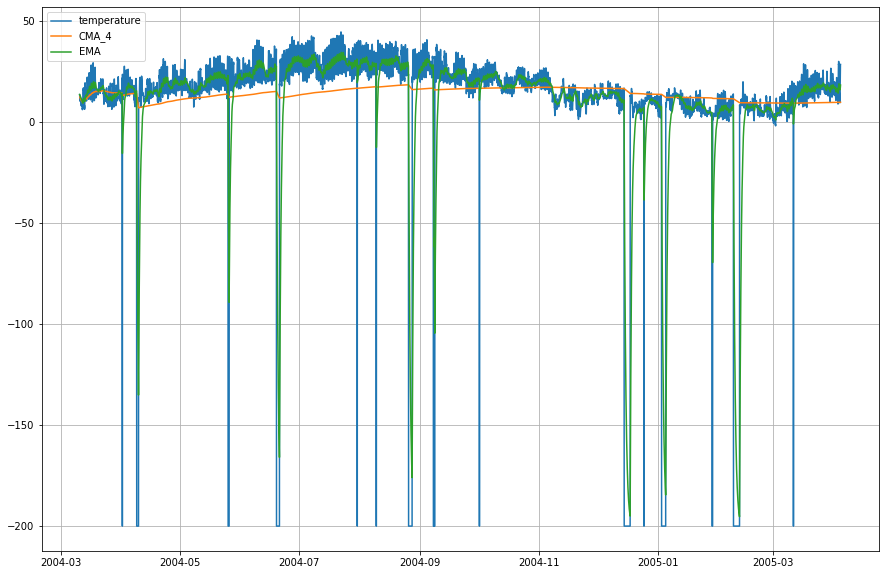

```python
plt.figure(figsize=[15,10])
plt.grid(True)
plt.plot(df_T['T'],label='temperature')
plt.plot(df_T['CMA_4'],label='CMA_4')
plt.plot(df_T['EMA'],label='EMA')
plt.legend(loc=2);
```

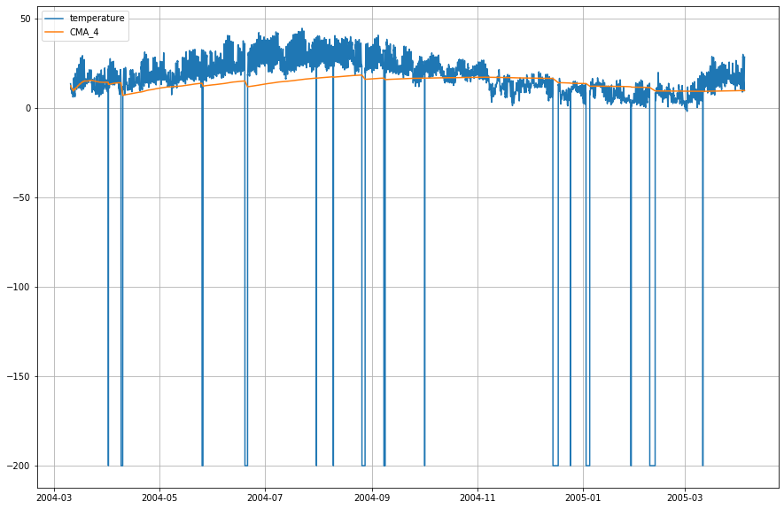

```python
df_T['DateTime']=df['DateTime']
#Let's now plot the actual temperature and the cumulative moving average wrt. time.

plt.figure(figsize=[15,10])
plt.grid(True)
plt.plot(df_T['T'],label='temperature')
plt.plot(df_T['CMA_4'],label='CMA_4')
plt.legend(loc=2)
```

```python
df_T
```

[output not shown]

9357 rows × 3 columns

```python
++++++++++++++++++++++++++++++++++++++++++++++++++++++++++++++++++++++++++++
```

```python
https://raw.githubusercontent.com/jbrownlee/Datasets/master/daily-total-female-births.csv
```